# Computing the center-outward quantile/superquantile function

The following codes are intended to help practicioners to test the entropic map as an empirical center-outward quantile function.

Without going any further, we state here the definitions we use. For more details, we refer to our paper defining center-outward superquantiles.

The entropic map can be seen as a regularized version of the center-outward quantile map. It is defined from $\pi_\epsilon$, the solution of Kantorovich regularized OT problem. $\pi_\epsilon$ is a joint probability measure for $(U,X)$ if $U\sim U_d$ and $X \sim \nu$. By barycentric projection, one can define, for any $u\in\mathcal{B}(0,1)$,

\begin{equation} Q_{\epsilon}(u) = \mathbb{E}_{\pi_\epsilon}\big( X \vert U = u \big), \end{equation} and \begin{equation} S_{\epsilon}(u) = \frac{1}{1-\Vert u \Vert} \int_{\Vert u \Vert}^1 Q_\epsilon\Big(t\frac{u}{\Vert u \Vert}\Big) dt. \end{equation}

These are our regularized versions of the center-outward quantile and superquantile functions respectively.

```python
import numpy as np
import matplotlib.pyplot as plt
import seaborn as sns
sns.set()

def quantile(eps,x,Y,v):
    '''
    Returns the entropic map at point x with regularization parameter eps.
    v is the optimal potential obtained with the Robbins-Monro algorithm for semi-discrete EOT
    '''
    arg = (v - cost(x, Y))/eps
    to_sum = np.exp(arg-np.max(arg))
    weights = to_sum/(np.sum(to_sum))
    return(np.sum(Y*weights.reshape(len(weights),1),axis=0))

def superquantile(eps,x,Y,v,N=100):
    '''
    Returns the superquantile map at point x from the "quantile" function defined just before
    N = number of points in the Riemann sum
    '''
    SQx = 0
    tau = np.linalg.norm(x)
    x = x/tau # norm x w.r.t. Ud
    t = np.linspace(tau,1,N) # subdivision of the interval [norm(x),1]
    for i in range(N):
        Qx = quantile(eps,t[i]*x,Y,v)
        SQx = SQx + Qx
    SQx = SQx / N
    return(SQx)

def cost(x,Y):
    """
    Squared euclidean distance between x and the J points of Y.
    if x is the ith point of the support of the distribution,
    the result is the ith line of the cost matrix.
    """
    diff = Y-x
    return(0.5*np.linalg.norm(diff, axis = 1)**2)

def c_transform(v, x, Y, nu, eps=0):
    """Calculate the c_transform of g"""
    if eps > 0:
        arg = (v - cost(x, Y))/eps
        M = np.max(arg)
        to_sum = np.exp(arg-M)*nu
        return(-eps*np.log(np.sum(to_sum)) - eps*M )
    else:
        cost_x = cost(x,Y)
        return(np.min(cost_x-v))

def grad_heps(v, x, Y, nu, eps=0):
    """
    Calculate the gradient h_eps
    """
    if eps > 0:
        arg = (v-cost(x,Y))/eps
        M = np.max(arg)
        pi = nu * np.exp(arg-M)
        pi = pi/pi.sum()
        return(nu-pi)
    else:
        cost_x = cost(x,Y)
        j_star = np.argmin(cost_x - v)
        to_return = nu.copy()
        to_return[j_star] = nu[j_star] - 1
        return(to_return)

def h_eps(v, x, Y, nu, eps=0):
    """
    Calculate the function h_eps whose expectation equals H_eps.
    """
    return(np.sum(v*nu)+c_transform(v,x,Y,nu,eps)-eps)

def Robbins_Monro_Algo(Y, eps=1, n_iter=10000):
    """
    robbins-monro algorithm for solving EOT
    """
    c = 0.51
    gamma = 1

    J = len(Y)
    nu = 1/J*np.ones(J)

    # Storage of recursive estimates.
    W_hat_storage = np.zeros(n_iter)
    h_eps_storage = np.zeros(n_iter)
    #bar_W_hat_storage = np.zeros(n_iter)
    #bar_h_eps_storage = np.zeros(n_iter)

    # Initialisation of dual vector v
    v = np.random.random(J)
    v = v - np.mean(v)

    # First sample to initiate
    Z = np.random.normal(0,1,2)
    Z = Z / np.sqrt(np.sum(Z**2))
    r = np.random.random()
    x_0 = r*Z

    W_hat_storage[0] = h_eps(v, x_0, Y, nu, eps)
    h_eps_storage[0] = h_eps(v, x_0, Y, nu, eps)

    # Robbins Monro algorithm
    for k in range(1,n_iter):
        #if k % 2000 == 0:
        #    print(k)
        # Sample from mu
        Z = np.random.normal(0,1,2)
        Z = Z / np.sqrt(np.sum(Z**2))
        r = np.random.random()
        x = r*Z

        # Update v
        v = v + gamma/((k+1)**c) * grad_heps(v, x, Y, nu, eps)
        #bar_v = ((k-1)/k)*bar_v + v/k
        #bar_h_eps_storage[k] = h_eps(bar_v, x, Y, nu, eps)

        # Storage of h_eps at point (x,g).
        h_eps_storage[k] = h_eps(v, x, Y, nu, eps)

        # approximation of Sinkhorn divergence
        W_hat_storage[k] = k/(k+1) * W_hat_storage[k-1] + 1/(k+1) * h_eps_storage[k]
        # bar_W_hat_storage[k] = k/(k+1) * bar_W_hat_storage[k-1] + 1/(k+1) * bar_h_eps_storage[k]

    L = [v, W_hat_storage]
    return(L)
```

# Simulate a sample Y in $\mathbb{R}^d$

#### When reusing, this is where you should change the codes, by inserting your data.

It must be of size `(n_samples,d)`.

```python
from sklearn.datasets import make_moons
```

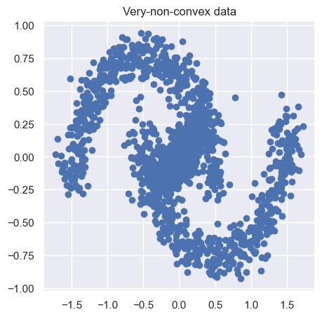

```python
X = make_moons(n_samples=1000, noise=0.1)[0]

mean = np.array([0.5,0.25])
mat = np.array([[0.8,0.2],[0.2,0.5]])/4
cov = np.dot(mat,mat)
Y = np.random.multivariate_normal(mean,cov,500)


plt.figure(figsize=(5,5))
Y = np.concatenate((X,Y))
Y = Y - np.mean(Y,axis=0)
plt.scatter(Y.T[0],Y.T[1])
plt.title("Very-non-convex data")
```

# 1. Computing $Q_\epsilon$ for any $u \in \mathcal{B}(0,1)$.

When using these codes, solving OT is a first step, computing the quantile/superquantile map is the second step.

#### STEP 1 : solving EOT

One can solve OT using any method from the POT library.

In this notebook, we used the stochastic gradient descent corresponding to *Bercu, Bigot, (2021), Asymptotic distribution and convergence rates of stochastic algorithms for entropic optimal transportation between probability measures, The Annals of Statistics.*

```python
eps = 0.001 # Regularization parameter
v1 = Robbins_Monro_Algo(Y,eps=eps, n_iter=30000)[0]
```

#### STEP 2 : compute quantiles and superquantiles

After that, for any $u \in \mathcal{B}(0,1)$, computing its image by the center-outward quantile map and/or superquantile map is immediate.

The quantile/superquantile function of some u depends on

- the data data Y,
- the second entropic Kantorovich potential v1,
- and the parameter eps.

# 2. Descriptive plots associated with `Y` in dimension `d=2`

The next cell details each step of the computation of descriptive plots associated with the center-outward quantile and superquantile functions.

For the sake of simplicity, one can reuse these codes by using the function defined at the end of this notebook, just after.

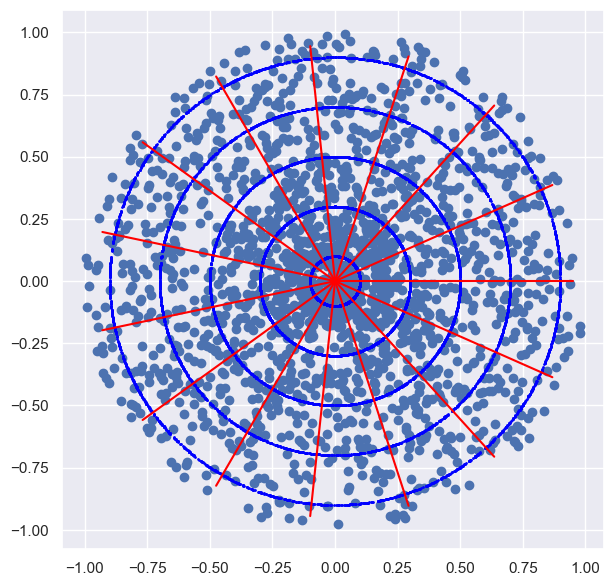

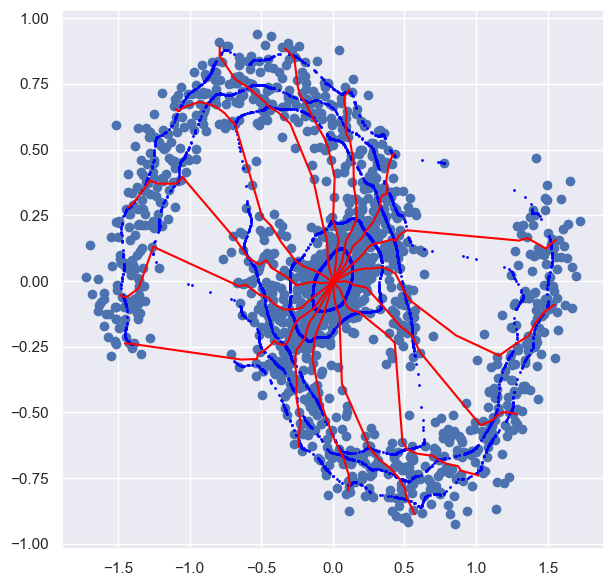

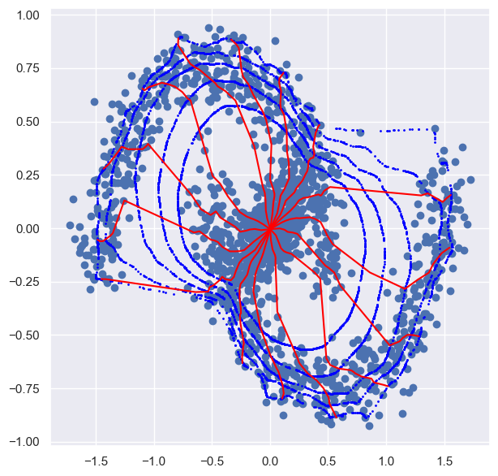

```python
eps = 0.001
rayons = np.array([0.1,0.3,0.5,0.7,0.9])

##################################
##################################
# STEP 1 : solving EOT

v1 = Robbins_Monro_Algo(Y,eps=eps, n_iter=30000)[0]

##################################
##################################
# STEP 2 : Transporting Ud with the MK quantile map and superquantile map
# (with the barycentric projection as a regularized quantile map)

sphere = []
Ud = []
for i in range(2000):
    Z = np.random.normal(0,1,2)
    Z = Z / np.sqrt(np.sum(Z**2))
    r = np.random.random()
    Ud.append(r*Z)
    sphere.append(Z)
Ud = np.array(Ud)
sphere = np.array(sphere)

# 1st plot
plt.figure(figsize=(7,7))
plt.scatter(Ud.T[0],Ud.T[1],label="$U_d$")
N = 15
N2 = 20
angles = 2*np.pi*np.arange(N)/N
for k in range(N):
    theta = angles[k]
    r = np.arange(N2)/N2
    us = np.array([[r*np.cos(theta)][0],[r*np.sin(theta)][0]])
    plt.plot(us[0],us[1],color='red')

for k in range(len(rayons)):
    tau = rayons[k]
    contour = tau*sphere
    plt.scatter(contour.T[0],contour.T[1],color="blue",s=1)

##################################
# we compute the regularized quantile contours associated with entropic optimal transport
##################################

n = 1000

contours_quantiles = []
contours_superquantiles = []
for tau in rayons:
    CQ1 = []
    CSQ1 = []
    normCQ1 = np.zeros(n)
    normCSQ1 = np.zeros(n)

    for i in range(n):
        # simulate uniformly on the sphere
        Z = np.random.normal(0,1,2)
        Z = Z / np.sqrt(np.sum(Z**2))
        u = tau * Z
        # Contour quantile of order tau for Y1
        TZ = quantile(eps,u,Y,v1)
        CQ1.append( TZ )
        # Contour superquantile of order tau for Y1
        TZ = superquantile(eps,u,Y,v1)
        CSQ1.append( TZ  )

    CQ1 = np.array(CQ1)
    CSQ1 = np.array(CSQ1)
    contours_quantiles.append(CQ1)
    contours_superquantiles.append(CSQ1)

contours_superquantiles = np.array(contours_superquantiles)
contours_quantiles = np.array(contours_quantiles)

##################################
# after that, it's all about vizualisation stuff
##################################

# 2nd plot
plt.figure(figsize=(7,7))
plt.scatter(Y.T[0],Y.T[1],label = "Y")

for k in range(len(rayons)):
    contour =  contours_quantiles[k]
    plt.scatter(contour.T[0],contour.T[1],s=1,color = "blue")

signcurve = np.zeros((N2,2))
for k in range(N):
    theta = angles[k]
    r = np.arange(N2)/N2
    for j in range(N2):
        u = np.array([r[j]*np.cos(theta),r[j]*np.sin(theta)])
        TZ = quantile(eps,u,Y,v1)
        signcurve[j,:] = TZ
    plt.plot(signcurve.T[0],signcurve.T[1],color='red')

# 3rd plot
plt.figure(figsize=(7,7))
plt.scatter(Y.T[0],Y.T[1],label = "Y")
for k in range(len(rayons)):
    contour = contours_superquantiles[k]
    plt.scatter(contour.T[0],contour.T[1],s=1,color = "blue")

signcurve = np.zeros((N2,2))
for k in range(N):
    theta = angles[k]
    r = np.arange(N2)/N2
    for j in range(N2):
        u = np.array([r[j]*np.cos(theta),r[j]*np.sin(theta)])
        TZ = quantile(eps,u,Y,v1)
        signcurve[j,:] = TZ
    plt.plot(signcurve.T[0],signcurve.T[1],color='red')
```

# A single function for descriptive plots

In dimension $d=2$, the next function can be used to draw these descriptive plots for any scatterplot $Y$ of size `(n_samples,2)`.

```python
def descriptiv_plots(Y,superplot=True,Udplot=True):
    d = 2
    eps = 0.001
    rayons = np.array([0.1,0.3,0.5,0.7,0.9])

    ##################################
    ##################################
    # STEP 1 : solving EOT
    v1 = Robbins_Monro_Algo(Y,eps=eps, n_iter=30000)[0]

    ##################################
    ##################################
    # STEP 2 : Transporting Ud with the MK quantile map and superquantile map
    # (with the barycentric projection as a regularized quantile map)

    sphere = []
    Ud = []
    for i in range(2000):
        Z = np.random.normal(0,1,d)
        Z = Z / np.sqrt(np.sum(Z**2))
        r = np.random.random()
        Ud.append(r*Z)
        sphere.append(Z)
    Ud = np.array(Ud)
    sphere = np.array(sphere)
    N = 15
    N2 = 20
    angles = 2*np.pi*np.arange(N)/N

    if (Udplot==True):
        plt.figure(figsize=(7,7))
        plt.scatter(Ud.T[0],Ud.T[1],label="$U_d$")
        for k in range(N):
            theta = angles[k]
            r = np.arange(N2)/N2
            us = np.array([[r*np.cos(theta)][0],[r*np.sin(theta)][0]])
            plt.plot(us[0],us[1],color='red')

        for k in range(len(rayons)):
            tau = rayons[k]
            contour = tau*sphere
            plt.scatter(contour.T[0],contour.T[1],color="blue",s=1)

    ##################################
    # we compute the regularized quantile contours associated with entropic optimal transport
    ##################################

    n = 1000

    contours_quantiles = []
    contours_superquantiles = []
    for tau in rayons:
        CQ1 = []
        CSQ1 = []

        for i in range(n):
            # simulate uniformly on the sphere
            Z = np.random.normal(0,1,2)
            Z = Z / np.sqrt(np.sum(Z**2))
            u = tau * Z
            # Contour quantile of order tau for Y1
            TZ = quantile(eps,u,Y,v1)
            CQ1.append( TZ )
            # Contour superquantile of order tau for Y1
            TZ = superquantile(eps,u,Y,v1)
            CSQ1.append( TZ  )

        CQ1 = np.array(CQ1)
        CSQ1 = np.array(CSQ1)
        contours_quantiles.append(CQ1)
        contours_superquantiles.append(CSQ1)

    contours_superquantiles = np.array(contours_superquantiles)
    contours_quantiles = np.array(contours_quantiles)

    ##################################
    # after that, it's all about vizualisation stuff
    ##################################

    plt.figure(figsize=(7,7))
    plt.scatter((Y).T[0],(Y).T[1],label = "Y")

    for k in range(len(rayons)):
        contour = ( contours_quantiles[k] )
        plt.scatter(contour.T[0],contour.T[1],s=1,color = "blue")

    signcurve = np.zeros((N2,2))
    for k in range(N):
        theta = angles[k]
        r = np.arange(N2)/N2
        for j in range(N2):
            u = np.array([r[j]*np.cos(theta),r[j]*np.sin(theta)])
            TZ = quantile(eps,u,Y,v1)
            signcurve[j,:] = TZ
        plt.plot(signcurve.T[0],signcurve.T[1],color='red')

    if (superplot==True):
        plt.figure(figsize=(7,7))
        plt.scatter((Y).T[0],(Y).T[1],label = "Y")
        for k in range(len(rayons)):
            contour = contours_superquantiles[k]
            plt.scatter(contour.T[0],contour.T[1],s=1,color = "blue")


        signcurve = np.zeros((N2,2))
        for k in range(N):
            theta = angles[k]
            r = np.arange(N2)/N2
            for j in range(N2):
                u = np.array([r[j]*np.cos(theta),r[j]*np.sin(theta)])
                TZ = quantile(eps,u,Y,v1)
                signcurve[j,:] = TZ
            plt.plot(signcurve.T[0],signcurve.T[1],color='red')
```

By default, the function draws the three descriptive plots.

If `superplot=False`, the one with superquantiles contours is hidden.

If `Udplot=False`, the one with the reference distribution is hidden.

By using the `boxplot function` from `matplotlib`, and by selecting the `positions` argument accordingly to your data, one can combine univariate and bivariate boxplots through a single vizualisation.

[output not shown]

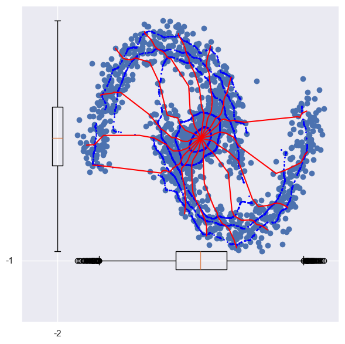

```python
descriptiv_plots(Y,superplot=False,Udplot=False)
plt.boxplot(Y.T[0],vert=False,positions=[-1])
plt.boxplot(Y.T[1],positions=[-2])
```